# RNA sequence analysis by Limma voom

# Quality control

Now that we have got rid of the lowly expressed genes and have our counts stored in a `DGEList` object, we can look at a few different plots to check that the data is good quality, and that the samples are as we would expect.

```r
y$samples$lib.size
```

```
##  [1] 2161954 2273832 1637900 1905575 1347164 1729611 2481612 2225663 2928785
## [10] 1918109  859638  890380 3437085 2972168 2282805 1844922 2373082 2730841
## [19] 1955915 3114150  957259 2535572  849562  864190 2332923 1059520 2283521
## [28] 2617012 2701030 2408586 2061360 2102191 1023356  956242  958064  921486
## [37] 1155669 1086364 2401308 2510391 2278396 1885133 3008536 2340360 3171972
## [46] 1943939  790033
```

We can also plot the library sizes as a barplot to see whether there are any major discrepancies between the samples more easily

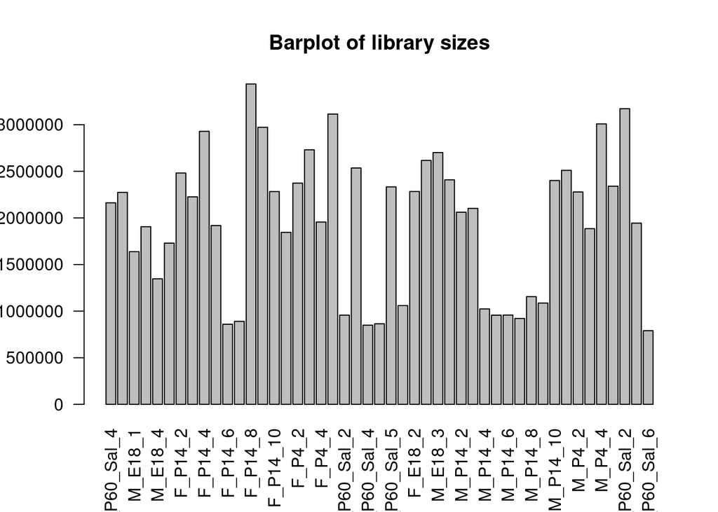

```r
# The names argument tells the barplot to use the sample names on the x-axis
# The las argument rotates the axis names
barplot(y$samples$lib.size,names=colnames(y),las=2)
# Add a title to the plot
title("Barplot of library sizes")
```

Count data is not normally distributed, so if we want to examine the distributions of the raw counts we need to log the counts. Next we’ll use box plots to check the distribution of the read counts on the log2 scale. We can use the `cpm` function to get log2 counts per million, which are corrected for the different library sizes. The `cpm` function also adds a small offset to avoid taking log of zero.

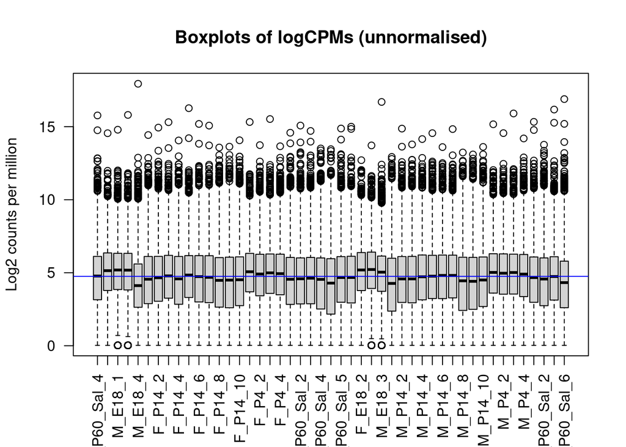

```r
# Get log2 counts per million
logcounts <- cpm(y,log=TRUE)
# Check distributions of samples using boxplots
boxplot(logcounts, xlab="", ylab="Log2 counts per million",las=2)
# Let's add a blue horizontal line that corresponds to the median logCPM
abline(h=median(logcounts),col="blue")
title("Boxplots of logCPMs (unnormalised)")
```

From the boxplots we see that overall the density distributions of raw log-intensities are not identical but still not very different. If a sample is really far above or below the blue horizontal line we may need to investigate that sample further. Another kind of QC plot that is helpful in checking for dodgy samples is a relative log expression [(RLE) plot](https://www.ncbi.nlm.nih.gov/pmc/articles/PMC5798764/), which can be generated with `plotRLE` from the EDASeq package